# Preparation 10 – Activity 8

Name

16 February, 2022

## `{stringr}`

The `starwars` dataset is loaded with the `{tidyverse}` and contains information from the Star Wars API on many Star Wars characters. For this Preparation, we will be focusing on the `hair_color`, `skin_color`, and `eye_color` variables.

```r
starwars
```

```
## # A tibble: 87 x 14
##    name    height  mass hair_color  skin_color eye_color birth_year sex   gender
##    <chr>    <int> <dbl> <chr>       <chr>      <chr>          <dbl> <chr> <chr>
##  1 Luke S…    172    77 blond       fair       blue            19   male  mascu…
##  2 C-3PO      167    75 <NA>        gold       yellow         112   none  mascu…
##  3 R2-D2       96    32 <NA>        white, bl… red             33   none  mascu…
##  4 Darth …    202   136 none        white      yellow          41.9 male  mascu…
##  5 Leia O…    150    49 brown       light      brown           19   fema… femin…
##  6 Owen L…    178   120 brown, grey light      blue            52   male  mascu…
##  7 Beru W…    165    75 brown       light      blue            47   fema… femin…
##  8 R5-D4       97    32 <NA>        white, red red             NA   none  mascu…
##  9 Biggs …    183    84 black       light      brown           24   male  mascu…
## 10 Obi-Wa…    182    77 auburn, wh… fair       blue-gray       57   male  mascu…
## # … with 77 more rows, and 5 more variables: homeworld <chr>, species <chr>,
## #   films <list>, vehicles <list>, starships <list>
```

### Hair Color Frequencies

```r
starwars %>%
  drop_na(hair_color) %>%
  group_by(hair_color) %>%
  summarise(n = n()) %>%
  arrange(n) %>%
  print(n = length(hair_color))
```

```
## Error in get_n_print(n, nrow(x)): object 'hair_color' not found
```

Say that we wish to treat each color as a unique instance so if a character has two shades present in their hair, we would count each shade separately. What we need to do is separate the `hair_color` column into individual columns, then restructure so that we have this information presented in a long format so that it will work within our data pipeline.

From the restructuring datasets materials earlier this semester, we would do the following (note that we are only *select*ing the column of interest to help focus the output):

```r
restructure_method <- starwars %>%
  select(hair_color) %>%
  separate(hair_color,
           into =  c("hair_first", "hair_second")) %>%
  pivot_longer(cols = everything(),
               names_to = "hair_order",
               values_to = "hair_color",
               values_drop_na = TRUE) %>%
  select(hair_color)
restructure_method
```

```
## # A tibble: 85 x 1
##    hair_color
##    <chr>
##  1 blond
##  2 none
##  3 brown
##  4 brown
##  5 grey
##  6 brown
##  7 black
##  8 auburn
##  9 white
## 10 blond
## # … with 75 more rows
```

```r
## Alternatively... so clean!
#
# starwars %>%
#   select(hair_color) %>%
#   separate_rows(hair_color)
```

In the code chunk below, you are provided with a character vector of the original `hair_color` column.

```r
hair_vector <- starwars %>%
  pull(hair_color)
```

Use `{stringr}` functions to *split* the multiple colors in the pipeline below (i.e., replace the two `___` with the appropriate code).

```r
str_hair <- hair_vector %>%
  str_split(pattern = ",") %>%
  unlist() # converts the list to a vector

str_hair
```

```
##  [1] "blond"   NA        NA        "none"    "brown"   "brown"   " grey"
##  [8] "brown"   NA        "black"   "auburn"  " white"  "blond"   "auburn"
## [15] " grey"   "brown"   "brown"   NA        NA        "brown"   "brown"
## [22] "white"   "grey"    "black"   "none"    "none"    "black"   "none"
## [29] "none"    "auburn"  "brown"   "brown"   "none"    "brown"   "none"
## [36] "blond"   "none"    "none"    "none"    "brown"   "black"   "none"
## [43] "black"   "black"   "none"    "none"    "none"    "none"    "none"
## [50] "none"    "none"    "white"   "none"    "black"   "none"    "none"
## [57] "none"    "none"    "none"    "black"   "brown"   "brown"   "none"
## [64] "black"   "black"   "brown"   "white"   "black"   "black"   "blonde"
## [71] "none"    "none"    "none"    "white"   "none"    "none"    "none"
## [78] "none"    "none"    "none"    "brown"   "brown"   "none"    "none"
## [85] "black"   "brown"   "brown"   "none"    "unknown" "brown"
```

The code chunk below is to compare your solution to the “old method”. You do not need to add any code; however, verify that you understand what the code is doing.

```r
restructure_table <- restructure_method %>%
  drop_na(hair_color) %>%
  group_by(hair_color) %>%
  summarise(n = n())

str_table <- tibble(hair_color = str_hair) %>%
  drop_na(hair_color) %>%
  group_by(hair_color) %>%
  summarise(n = n())

waldo::compare(restructure_table, str_table)
```

```
##  `attr(old, 'row.names')[7:9]`: 7 8 9
## `attr(new, 'row.names')[7:11]`: 7 8 9 10 11
##
## `old$hair_color[1:3]`:                  "auburn" "black" "blond"
## `new$hair_color[1:5]`: " grey" " white" "auburn" "black" "blond"
##
## `old$n`:     3 13 3 1 19 3 37 1 and 1 more...
## `new$n`: 2 1 3 13 3 1 19 1 37 1           ...
```

Did you get `No differences`?

#### Challenge: Skin Color

Can you get the frequencies of the separate values for the variable `skin_color`?

```r
str_skin <- starwars %>%
  pull(skin_color) %>%
  str_split(pattern = ", ") %>%
  unlist()
str_skin
```

```
##   [1] "fair"          "gold"          "white"         "blue"
##   [5] "white"         "light"         "light"         "light"
##   [9] "white"         "red"           "light"         "fair"
##  [13] "fair"          "fair"          "unknown"       "fair"
##  [17] "green"         "green-tan"     "brown"         "fair"
##  [21] "fair"          "green"         "pale"          "fair"
##  [25] "metal"         "green"         "dark"          "light"
##  [29] "brown mottle"  "fair"          "fair"          "brown"
##  [33] "grey"          "fair"          "mottled green" "fair"
##  [37] "orange"        "grey"          "green"         "fair"
##  [41] "blue"          "grey"          "grey"          "red"
##  [45] "dark"          "fair"          "red"           "pale"
##  [49] "blue"          "blue"          "grey"          "white"
##  [53] "blue"          "grey"          "green"         "yellow"
##  [57] "dark"          "pale"          "green"         "brown"
##  [61] "dark"          "pale"          "white"         "orange"
##  [65] "blue"          "dark"          "light"         "fair"
##  [69] "green"         "yellow"        "yellow"        "light"
##  [73] "fair"          "tan"           "tan"           "fair"
##  [77] "green"         "yellow"        "brown"         "grey"
##  [81] "grey"          "fair"          "grey"          "blue"
##  [85] "silver"        "red"           "green"         "grey"
##  [89] "grey"          "red"           "blue"          "white"
##  [93] "brown"         "white"         "brown"         "light"
##  [97] "pale"          "grey"          "dark"          "light"
## [101] "light"         "none"          "unknown"       "light"
```

```r
tibble(skin_color = str_skin) %>%
  drop_na(skin_color) %>%
  group_by(skin_color) %>%
  summarise(n = n())
```

```
## # A tibble: 21 x 2
##    skin_color       n
##    <chr>        <int>
##  1 blue             8
##  2 brown            6
##  3 brown mottle     1
##  4 dark             6
##  5 fair            18
##  6 gold             1
##  7 green            9
##  8 green-tan        1
##  9 grey            12
## 10 light           11
## # … with 11 more rows
```

## `{forcats}`

This will continue using the `starwars` dataset.

## Plot Frequencies of Eye Color

Plot a bar chart of the variable `eye_color`. However, eye colors that have less than 2 observations should be *lump*ed into an “Other” color. You do not need to separate the values of `eye_color`, but you must use `{forcats}` functions to create this plot.

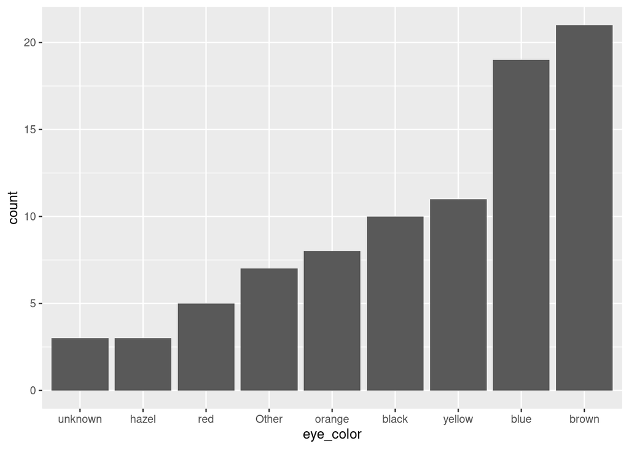

```r
starwars %>%
  mutate(eye_color = fct_lump(eye_color, prop = 0.03),
         eye_color = fct_infreq(eye_color),
         eye_color = fct_rev(eye_color)) %>%
  ggplot(mapping = aes(x = eye_color)) +  geom_bar()
```

Update your plot, using additional `{forcats}` functions, so that the bars are ordered by the heights (experiement with increasing and decreasing bar heights).

## `{lubridate}`

You will not be working with any particular dataset for these items.

### Calculate age

```r
my_birthday <- "2022-01-01"
```

Calculate your instructor’s birthday in *number of weeks*

```r
bradford_birthday <- "December 17, 1985"
```

```r
(today() - mdy(bradford_birthday)) %/% dweeks(1)
```

```
## [1] 1887
```

```r
(today() - mdy(bradford_birthday)) %/% ddays(7)
```

```
## [1] 1887
```

### Vector of days

```r
first_days_2021 <- as_datetime("2021-01-01") + months(0:11)

first_days_2021
```

```
##  [1] "2021-01-01 UTC" "2021-02-01 UTC" "2021-03-01 UTC" "2021-04-01 UTC"
##  [5] "2021-05-01 UTC" "2021-06-01 UTC" "2021-07-01 UTC" "2021-08-01 UTC"
##  [9] "2021-09-01 UTC" "2021-10-01 UTC" "2021-11-01 UTC" "2021-12-01 UTC"
```

Using your `first_days_2021` and `{lubridate}` functions, identify which day of the week these first days were (e.g., Monday). That is, `"2021-01-01"` occurred on a Friday so your output should say `"Friday".`

```r
first_days_wday <- lubridate::wday(first_days_2021, label = TRUE)
first_days_wday
```

```
##  [1] Fri Mon Mon Thu Sat Tue Thu Sun Wed Fri Mon Wed
## Levels: Sun < Mon < Tue < Wed < Thu < Fri < Sat
```

## Knitting

To download this file and then upload to Blackboard, do the following:

1. Knit your report and verify that it looks as you want it to (that is, graphs and other output are displaying as you intended),
2. On line 5, change the `output` from “html_document” to “word_document”,
3. Knit your report again to create your `preparation10.docx` file,
4. Download this document by checking the box next to this `docx` file in the **Files** pane (lower-right-hand pane), then click More > Export…